# Wstęp do programowania

Przetwarzanie danych

Author

Krzysztof Dyba

# Wczytywanie i zapisywanie danych

Pierwszy etap w analizie danych to wczytanie (importowanie) danych. R obsługuje różne formaty plików, takie jak pliki tekstowe, CSV (*comma-separated values*) czy arkusze kalkulacyjne. Podstawową funkcją do wczytywania danych tabelarycznych jest `read.table()` i jej pochodne.

## Ścieżka bezwzględna i względna

Można wyróżnić dwa sposoby dostępu do lokalizacji plików na dysku:

1. Ścieżka bezwzględna (*absolute path*).
2. Ścieżka względna (*relative path*).

Ścieżka bezwzględna określa pełną, dokładną lokalizację pliku, począwszy od katalogu głównego systemu plików (`C:/` w systemie Windows lub `/` w systemach uniksowych). Największym ograniczeniem jest zależność od struktury katalogów na dysku i systemu. Po przeniesieniu danych na inny komputer lub system operacyjny, ścieżka ta przestaje być prawidłowa. Oznacza to, że nie jest przenośna i z tego powodu ten sposób nie jest zalecany!

```r
# ścieżka bezwzględna
"C:/Users/Krzysztof/Dokumenty/dane/plik.csv"
```

Natomiast ścieżka względna określa położenie pliku względem bieżącego katalogu roboczego (*working directory*), dzięki czemu jest przenośna między systemami, o ile struktura plików względem katalogu roboczego pozostaje taka sama. Do sprawdzenia aktualnego katalogu roboczego służy funkcja `getwd()`, a do zmiany funkcja `setwd()`.

```r
# ustawienie nowego katalogu roboczego
setwd("C:/Users/Krzysztof/Dokumenty")

# ścieżka względna
dane = "dane/plik.csv"
```

Ścieżki do plików definiowane są jako tekst, zatem wymagany jest zapis w cudzysłowie.

## Wczytywanie

W katalogu `dane` znajdziesz plik tekstowy o nazwie `iris.txt`, który zawiera pomiary cech (atrybutów) trzech różnych gatunków irysów. Zacznijmy od sprawdzenia w jakiej lokalizacji (tj. katalogu roboczym) aktualnie się znajdujemy.

```r
getwd()
```

```
#> "C:/Users/Krzysztof/Desktop/intro2025/cwiczenia"
```

Plik `iris.txt` zapisany jest w równoległym (na tym samym poziomie hierarchii) katalogu `dane`, więc musimy wykorzystać składnię `..` do przejścia o jeden poziom wyżej, a następnie wskazać lokalizację podrzędną do tego pliku (`dane/iris.txt`).

```r
plik = "../dane/iris.txt"
```

Spróbujmy go teraz wczytać używając funkcji `read.table()`. Przed importem danych należy sprawdzić następujące elementy:

- Czy plik posiada nazwy kolumn `header`?
- Jaki znak jest separatorem kolumn `sep` (spacja, średnik, przecinek)?
- Jaki znak jest separatorem dziesiętnym liczb `dec` (kropka czy przecinek)?

W zależności od odpowiedzi na te pytania, powinniśmy ustawić odpowiednie wartości argumentów funkcji, aby plik został prawidłowo wczytany. Jeśli tego nie zrobimy, to przykładowo wszystkie wartości zostaną wczytane do jednej kolumny albo liczby zostaną wczytane jako tekst.

```r
iris = read.table(plik, header = TRUE, sep = " ", dec = ".")
```

Plik został wczytany jako ramka danych. Do weryfikacji jego zawartości możemy wykorzystać funkcję `str()`, która wyświetli jego strukturę, czyli podstawowe informacje o klasie obiektu, liczbie obserwacji (wierszy) oraz zmiennych (kolumn), typie danych i przykładowe wartości z kolumn.

```r
str(iris)
```

```
'data.frame':   150 obs. of  5 variables:
 $ Sepal.Length: num  5.1 4.9 4.7 4.6 5 5.4 4.6 5 4.4 4.9 ...
 $ Sepal.Width : num  3.5 3 3.2 3.1 3.6 3.9 3.4 3.4 2.9 3.1 ...
 $ Petal.Length: num  1.4 1.4 1.3 1.5 1.4 1.7 1.4 1.5 1.4 1.5 ...
 $ Petal.Width : num  0.2 0.2 0.2 0.2 0.2 0.4 0.3 0.2 0.2 0.1 ...
 $ Species     : chr  "setosa" "setosa" "setosa" "setosa" ...
```

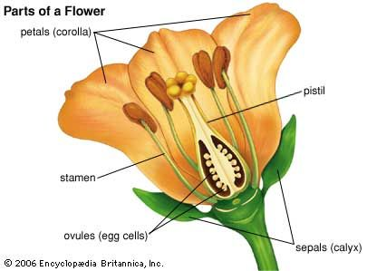

Encyclopædia Britannica, 2006

Jak wspomniano wcześniej, `read.table()` jest funkcją podstawową do wczytywania różnego rodzaju plików tabelarycznych. Jednak, istnieją jej dwa warianty do plików CSV z wartościami (kolumnami) oddzielanymi przecinkami. Są to `read.csv()` oraz `read.csv2()`, które przyjmują różne domyślne wartości argumentów. W krajach europejskich (w tym w Polsce) preferowany jest ten drugi wariant, ponieważ domyślnie przecinek pełni funkcję separatora dziesiętnego liczby, a nie kolumn jak definiuje to standard pliku CSV.

## Zapisywanie

Dane oczywiście możemy zapisać (eksportować) w różnych formatach analogiczne wykorzystując funkcję `write.table()` oraz jej pochodne, np. `write.csv()`. Jako argumenty funkcji należy podać obiekt do zapisania oraz ścieżkę, w której zostanie on zapisany. Oprócz tego, można zdefiniować inne argumenty (np. separator dziesiętny czy separator kolumn).

```r
write.table(iris, "../dane/iris.csv", sep = ";", dec = ",", row.names = FALSE)
```

Plik został zapisany w katalogu `dane`.

# Obsługa ramek danych

## Inspekcja

Po wczytaniu danych następnym krokiem jest zapoznanie się z nimi. Jest to konieczny etap, aby zrozumieć ich strukturę oraz zawartość. W R mamy dostępny szereg możliwości:

- `str()` – wyświetla strukturę obiektu.
- `summary()` – zwraca podstawowe statystyki opisowe.
- `head()` – domyślnie wyświetla pierwsze 6 wierszy zbioru danych.
- `tail()` – domyślnie wyświetla ostatnie 6 wierszy zbioru danych.
- `unique()` – zwraca unikalne wartości.
- `dim()` – zwraca liczbę wierszy i kolumn.
- `ncol()` – zwraca liczbę kolumn.
- `nrow()` – zwraca liczbę wierszy.
- `rownames()` – zwraca (lub modyfikuje) nazwy wierszy.
- `colnames()` – zwraca (lub modyfikuje) nazwy kolumn.
- `class()` – zwraca klasę obiektu.

## Selekcja kolumn i wierszy

Do selekcji kolumn i wierszy z ramki danych wykorzystuje się nawiasy kwadratowe `[]`. Wynik selekcji można zapisać do nowej zmiennej, np. `iris_sel` albo nadpisać istniejący obiekt (jednak należy uważać).

```r
# wybierz 5 pierwszych wierszy
iris[1:5, ]

# wybierz kolumny o indeksach 1, 2 i 5
iris[, c(1, 2, 5)]

# wybierz kolumnę o nazwie "Species"
iris[, "Species"]

# wybór kolumny używając $
iris$Species
```

Obserwacje znajdujące się w wierszach można także filtrować na podstawie określonych warunków.

```r
# wybierz obserwacje z gatunku "setosa"
iris[iris$Species == "setosa", ]

# wybierz obserwacje spełniające oba warunki
# oraz wybierz tylko kolumnę "Species"
iris[iris$Sepal.Length > 7 & iris$Sepal.Width > 3, "Species"]
```

Operatory logiczne zwracają wartości logiczne `TRUE` i `FALSE` dla każdego testowanego elementu. Jednak, w przetwarzaniu danych często istotniejsze jest określenie pozycji (indeksów) elementów, które spełniają określony warunek, to znaczy przyjmują wyłącznie wartość `TRUE`. W takim przypadku bardzo przydatna jest funkcja `which()`, która zwraca indeksy elementów wektora logicznego, które mają wartość `TRUE`.

```r
# wektor logiczny o długości 150
x = iris$Sepal.Length < 5
```

```r
# zwraca indeksy elementów, które spełniły warunek
which(x)
```

```
 [1]   2   3   4   7   9  10  12  13  14  23  25  30  31  35  38  39  42  43  46
[20]  48  58 107
```

```r
which.min(iris$Sepal.Length)
```

```
[1] 14
```

```r
which.max(iris$Sepal.Length)
```

```
[1] 132
```

Zauważ, że funkcje `min()` oraz `max()` zwracają wartość minimalną oraz maksymalną, natomiast funkcje `which.min()` oraz `which.max()` zwracają ich indeksy!

## Sortowanie

Podstawową funkcją do sortowania wektorów w kolejności rosnącej lub malejącej jest `sort()`. Natomiast, do sortowania w ramce danych, a ściślej mówiąc uporządkowania danych według odpowiedniej kolejności, służy funkcja `order()`. Możliwe jest wykorzystanie jednej lub większej liczby kolumn do sortowania.

```r
# sortowanie rosnące
iris[order(iris$Sepal.Length), ]

# sortowanie malejące (znak minus)
iris[order(-iris$Sepal.Length), ]

# sortowanie według dwóch kolumn
iris[order(iris$Sepal.Length, iris$Sepal.Width), ]
```

## Przetwarzanie

Na ramce danych możemy wykonać różne transformacje, które polegają na tworzeniu nowych kolumn (zmiennych), modyfikowaniu istniejących, konwersji typów danych czy usuwaniu wierszy oraz kolumn.

### Dodawanie kolumn

Wykonanie określonych operacji (np. matematycznych czy warunkowych) może posłużyć do stworzenia nowych kolumn w zbiorze danych.

```r
# stworzenie nowej kolumny reprezentującej
# współczynnik długości do szerokości płatka
iris$petal_ratio = iris$Petal.Length / iris$Petal.Width
```

Możliwe jest również modyfikowanie wartości istniejących kolumn.

```r
# przeskalowanie wartości kolumny "Sepal.Length" przez 2
iris$Sepal.Length = iris$Sepal.Length * 2
```

### Zmiana nazw kolumn

Do zmiany nazw kolumn, ale także wyświetlania, służy funkcja `colnames()`. W celu zmiany wszystkich nazw, należy przypisać nowy wektor tekstowy o tej samej długości (liczbie nazw). Jeśli zmiana nazwy dotyczy wybranych kolumn, to należy zastosować indeksowanie lub operator porównawczy `==`.

```r
colnames(iris)
```

```
#> [1] "Sepal.Length" "Sepal.Width"  "Petal.Length" "Petal.Width"  "Species"
```

```r
# zmiana nazwy piątej kolumny
colnames(iris)[5] = "Gatunek"
colnames(iris)
```

```
#> [1] "Sepal.Length" "Sepal.Width"  "Petal.Length" "Petal.Width"  "Gatunek"
```

### Usuwanie kolumn

Usunięcie kolumn z ramki danych można przeprowadzić na dwa sposoby. Pierwszy, przez filtrację, co zostało wcześniej zademonstrowane. Drugi sposób polega na przypisaniu wybranej kolumnie pustej wartości `NULL`.

```r
# usunięcie kolumn "Species" z ramki danych
iris$Species = NULL

# usunięcie poprzez negatywną selekcję
iris = iris[, -5]
```

# Brakujące wartości

Brakujące wartości są oznaczone w R jako specjalne wartości `NA` (*Not Available*). Jest to fundamentalna koncepcja w analizie danych, ponieważ rzeczywiste zbiory danych często zawierają brakujące wartości z różnych powodów, np. błędy podczas pozyskiwania danych, brak odpowiedzi w ankiecie czy awaria sprzętu pomiarowego. Zazwyczaj przeprowadzenie operacji na zbiorach danych, które posiadają brakujące wartości nie jest możliwe (wynikiem będzie `NA`).

```r
# wektor z brakującymi wartościami
x = c(1, NA, 3, NA, 5)
sum(x)
```

```
[1] NA
```

## Identyfikacja

Podstawową funkcją do identyfikowania brakujących danych jest `is.na()`, która sprawdza, czy każdy element obiektu ma brakującą wartość `NA`. Jeśli wystąpiło `NA`, to zwraca wartość logiczną `TRUE` dla tego elementu.

```r
# czy element ma brakującą wartość?
is.na(x)
```

```
[1] FALSE  TRUE FALSE  TRUE FALSE
```

Przeciwieństwem wymienionej funkcji jest `complete.cases()`, która zwraca wartość `TRUE`, jeśli element obiektu posiada uzupełnioną wartość.

```r
# czy element ma wartość?
complete.cases(x)
```

```
[1]  TRUE FALSE  TRUE FALSE  TRUE
```

Aby określić liczbę brakujących wartości w wektorze wystarczy zsumować wartości logiczne `TRUE` (1), kiedy wstąpiło `NA` w funkcji `is.na()`.

```r
# zlicz brakujące wartości
sum(is.na(x))
```

```
[1] 2
```

## Obsługa

W sytuacji, kiedy napotkamy na brakujące wartości w naszym zbiorze danych, to koniecznie jest ich wykluczenie z analizy, aby wykonać obliczenia i otrzymać prawidłowe wyniki, co można wykonać na kilka sposobów. Wiele funkcji posiada argumenty do obsługi wartości `NA` (najczęściej `na.rm`). Ustawienie `na.rm = TRUE` powoduje, że funkcja usuwa wartości `NA` przed wykonaniem obliczeń.

```r
sum(x, na.rm = TRUE)
```

```
[1] 9
```

Jeśli funkcja nie posiada argumentu do usuwania brakujących wartości, to musimy zrobić to samodzielnie. W tym celu możemy wykorzystać poznaną funkcję `complete.cases()`, która zwróci tylko te wiersze z ramki danych, które posiadają wartości.

```r
df = data.frame(
  id = 1:5,
  imie = c("Ania", "Tomek", NA, "Dawid", "Zosia"),
  wiek = c(25, NA, 15, 20, NA)
)
```

```r
# wiersze zawierające NA zostały pominięte
df[complete.cases(df), ]
```

```
  id  imie wiek
1  1  Ania   25
4  4 Dawid   20
```

Podobne działanie posiada funkcja `na.omit()`, która usuwa wiersze z brakującymi wartościami. W alternatywnym podejściu, zamiast usuwać brakujące dane, moglibyśmy przypisać im jakąś określoną wartość, np. średnią, medianę czy wartość zdefiniowaną przez użytkownika.

W przypadku, gdy pewna kolumna (zmienna) zawiera dużo brakujących wartości, to warto zastanowić się czy nie lepiej usunąć całą kolumnę niż usuwać wiele wierszy (obserwacji).

# Agregacja danych

**Agregacja danych** to proces polegający na podsumowaniu danych, obejmujący ich generalizację do formy zestawienia najczęściej z uwzględnieniem kategorii (grup) w nich występujących lub przedziałów czasowych. W tym celu używa się różnych miar statystycznych, takich jak suma, średnia, mediana czy wartość minimalna i maksymalna. Wynikiem tego procesu jest przekształcenie danych wejściowych w łatwiejszą do interpretacji formę.

Funkcja `table()` umożliwia stworzenie prostej tabeli będącej zestawieniem wystąpień czynników (kategorii).

```r
table(iris$Species)
```

```
    setosa versicolor  virginica
        50         50         50
```

Bardziej zaawansowane możliwości oferuje funkcja `aggregate()`, która dokonuje podsumowania danych na podstawie zmiennej grupującej i wykorzystuje określoną funkcję (np. średnia) do każdego podzbioru. Finalnie wynik zwracany jest w postaci ramki danych.

W funkcji `aggregate()` jako pierwszy argument należy podać formułę, którą definiuje się używając znaku tyldy `~`. Po lewej stronie tyldy określamy kolumny do agregacji, natomiast po prawej stronie wskazujemy zmienną grupującą. Oprócz tego, należy wskazać zbiór danych (`data`) oraz funkcję grupującą (`FUN`). Zobaczymy to na następującym przykładzie.

```r
aggregate(Sepal.Length ~ Species, data = iris, FUN = mean)
```

```
     Species Sepal.Length
1     setosa        5.006
2 versicolor        5.936
3  virginica        6.588
```

# Łączenie danych

**Łączenie danych** to proces integracji danych z wielu źródeł (np. różnych tabel) w jeden, ujednolicony zestaw danych oparty na wspólnych atrybutach lub kluczach, np. ID. Wyróżnić można kilka rodzajów połączeń:

- Wewnętrzne (*inner join*) – zachowuje wiersze z pasującymi kluczami w obu zestawach danych.
- Lewe (*left join*) – zachowuje wszystkie wiersze z lewego zestawu danych i dopasowania z prawego.
- Prawe (*right join*) – zachowuje wszystkie wiersze z prawego zestawu danych i dopasowania z lewego.
- Pełne (*full join*) – zachowuje wszystkie wiersze z obu zestawów danych.

Podstawowym narzędziem do łączenia ramek danych na podstawie wspólnego atrybutu (klucza) jest funkcja `merge()`. Wymaga ona wskazania pierwszej (`x`) oraz drugiej (`y`) ramki danych i atrybutu łączącego (`by`). Do wyboru rodzaju połączenia służą argumenty `all.x` (lewe połączenie), `all.y` (prawe połączenie), `all` (pełne połączenie). Domyślnie wykonywane jest połączenie wewnętrzne.

```r
df1 = data.frame(
  ID = c(1, 2, 3, 4),
  imie = c("Ania", "Tomek", "Dawid", "Zosia")
)

df2 = data.frame(
  ID = c(1, 2, 3, 5),
  wiek = c(25, 22, 15, 20)
)

# połącz dwie tabele na podstawie ID
m = merge(df1, df2, by = "ID")
m
```

```
  ID  imie wiek
1  1  Ania   25
2  2 Tomek   22
3  3 Dawid   15
```

W przypadku gdy dane mamy uporządkowane i o takiej samej liczbie elementów, to możemy zastosować prostszy wariant łączenia używając funkcji `cbind()` (dodawanie kolumn) oraz `rbind()` (dodawanie wierszy).

```r
m = rbind(m, c(4, "Zosia", 25))
m
```

```
  ID  imie wiek
1  1  Ania   25
2  2 Tomek   22
3  3 Dawid   15
4  4 Zosia   25
```

```r
m = cbind(m, miasto = c("Warszawa", "Poznań", "Kraków", "Gdańsk"))
m
```

```
  ID  imie wiek   miasto
1  1  Ania   25 Warszawa
2  2 Tomek   22   Poznań
3  3 Dawid   15   Kraków
4  4 Zosia   25   Gdańsk
```

# Zadania

1. W sekcji “*Zapisywanie*” został zapisany na dysku plik `iris.csv`. Wczytaj go do sesji.
2. Dokonaj inspekcji wczytanego zbioru danych. W szczególności sprawdź strukturę danych, liczbę kolumn i wierszy, unikalne gatunki oraz statystyki opisowe. Odpowiedzi zapisz w formie komentarzy.
3. Znajdź ten gatunek irysów, którego wartość `Sepal.Length` jest większa niż 7 cm. Jaki to gatunek?
4. Który gatunek posiada najmniejszą wartość `Petal.Length` i ile wynosi ta wartość?
5. Która zmienna (kolumna) posiada największą wartość i ile wynosi ta wartość?
6. Policz ile jest obserwacji, dla których `Petal.Width` jest większe bądź równe 2 cm.
7. Do ramki danych dodaj nową kolumnę o nazwie `rzadki`. Przyjmie ona wartość `TRUE`, jeśli współczynnik `Petal.Length` do `Petal.Width` będzie większy od 6 (w przeciwnym razie `FALSE`).
8. Utwórz nową ramkę danych, która będzie posiadała tylko 10 obserwacji o największej wartości `Sepal.Length` posortowanych malejąco. Do utworzonej ramki danych dodaj nową kolumnę z ID od 1 do 10.
9. Ze zbioru wybierz gatunek `setosa` i zapisz go na dysku jako plik tekstowy o nazwie `setosa.txt`. Uprzednio zmień nazwy kolumn, aby nie zawierały `.`, ale `_` między słowami. Jako separator kolumn wykorzystaj przecinek, a jako separator dziesiętny kropkę. Pomiń zapisywanie ID obserwacji.